# Lab 13

## Temperature–moisture coupling across climate regimes

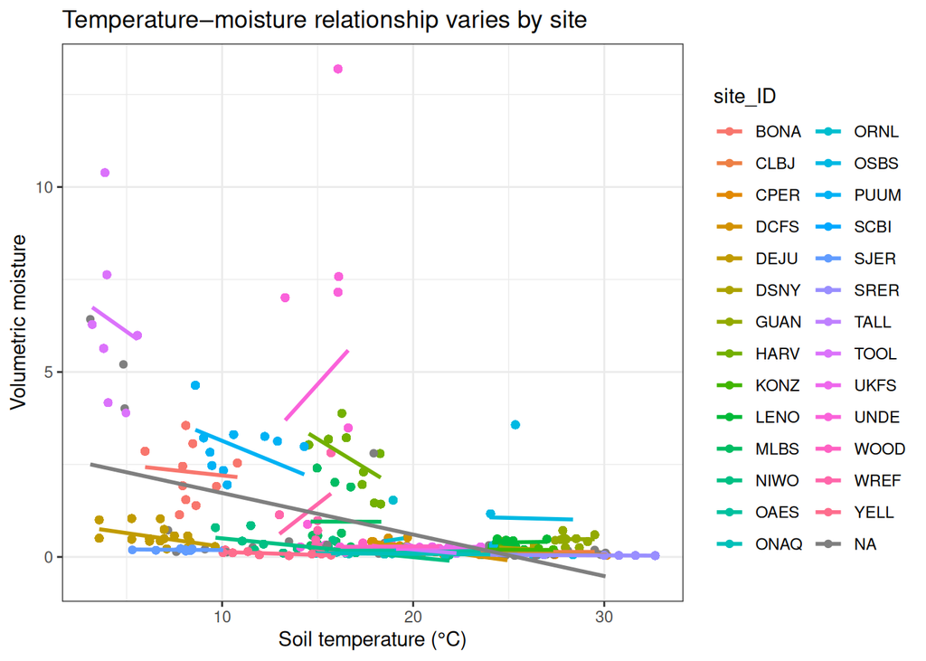

```r
p_tm <- ggplot(soil_env, aes(soilTemp, soilMoisture, color = site_ID)) +
  geom_point() +
  geom_smooth(method = "lm", se = FALSE) +
  labs(x = "Soil temperature (°C)", y = "Volumetric moisture",
       title = "Temperature–moisture relationship varies by site") +
  theme_bw()

p_tm
```

This highlights the soil temperature and how they differ depedning on the site. My ecological interpretation of this graph is that in grasslands (SRER, ONAQ), there is often warmer soils and drier conditions (shown by the negative slope). In other types of forests (HARV, UNDE), this coupling/ relationship may be weak or even positive depending on sampling time and location.

## Spatial visualization: latitude–longitude colored by pH

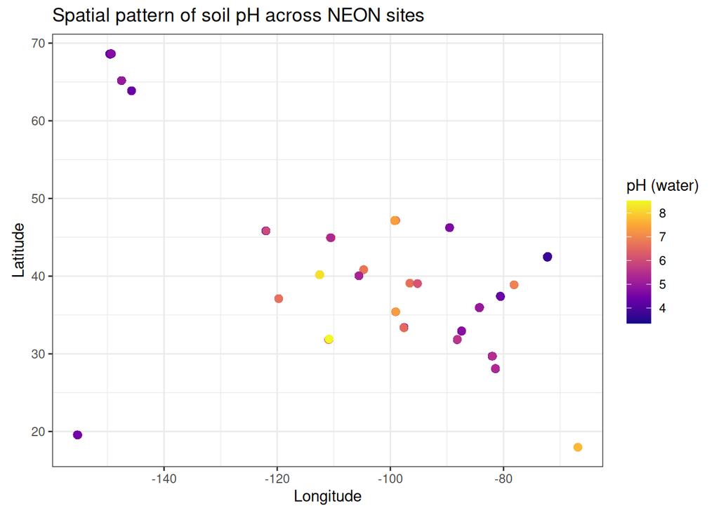

```r
p_map <- ggplot(soil_env, aes(decimalLongitude, decimalLatitude, color = soilInWaterpH)) +
  geom_point(size = 2) +
  scale_color_viridis_c(option = "plasma") +
  coord_quickmap() +
  labs(x = "Longitude", y = "Latitude", color = "pH (water)",
       title = "Spatial pattern of soil pH across NEON sites") +
  theme_bw()

p_map
```

This map shows the soil pH across latitude and longitude, and highlights biogeographic chemistry patterns.The Western (drier) sites can show higher pH, whereas in humid, organic-rich forests often have a lower pH. The map helps show the relationship between location and chemistry patterns.